# Week 2 - Homework

Aman Arora (amana4@illinois.edu)

## Exercise 1 (Using `lm`)

For this exercise we will use the `cats` dataset from the `MASS` package. You should use `?cats` to learn about the background of this dataset.

**(a)** Suppose we would like to understand the size of a cat’s heart based on the body weight of a cat. Fit a simple linear model in `R` that accomplishes this task. Store the results in a variable called `cat_model`. Output the result of calling `summary()` on `cat_model`.

```r
library(MASS)

cats = MASS::cats

cat_model = lm(Hwt~Bwt, data= cats)
summary(cat_model)
```

```
##
## Call:
## lm(formula = Hwt ~ Bwt, data = cats)
##
## Residuals:
##     Min      1Q  Median      3Q     Max
## -3.5694 -0.9634 -0.0921  1.0426  5.1238
##
## Coefficients:
##             Estimate Std. Error t value Pr(>|t|)
## (Intercept)  -0.3567     0.6923  -0.515    0.607
## Bwt           4.0341     0.2503  16.119   <2e-16 ***
## ---
## Signif. codes:  0 '***' 0.001 '**' 0.01 '*' 0.05 '.' 0.1 ' ' 1
##
## Residual standard error: 1.452 on 142 degrees of freedom
## Multiple R-squared:  0.6466, Adjusted R-squared:  0.6441
## F-statistic: 259.8 on 1 and 142 DF,  p-value: < 2.2e-16
```

**(b)** Output only the estimated regression coefficients. Interpret $\hat{\beta_0}$ and $\beta_1$ in the *context of the problem*. Be aware that only one of those is an estimate.

```r
cat_model$coefficients
```

```
## (Intercept)         Bwt
##  -0.3566624   4.0340627
```

The $\hat{\beta_0}$ is the the estimated heart weight if the body weight of the cat is 0. $\beta_1$ is the “true” rate of change of heart weight with body weight.

**(c)** Use your model to predict the heart weight of a cat that weights **3.1** kg. Do you feel confident in this prediction? Briefly explain.

```r
predict(cat_model, newdata = data.frame(Bwt = 3.1))
```

```
##        1
## 12.14893
```

Since the predictor variable is in the range of data, the prediction is interpolation based and reliable.

**(d)** Use your model to predict the heart weight of a cat that weights **1.5** kg. Do you feel confident in this prediction? Briefly explain.

```r
predict(cat_model, newdata = data.frame(Bwt = 1.5))
```

```
##        1
## 5.694432
```

Since the predictor variable is out of the range of data, the prediction is extrapolation based and this indicates less confidence than interploation based prediction.

**(e)** Create a scatterplot of the data and add the fitted regression line. Make sure your plot is well labeled and is somewhat visually appealing.

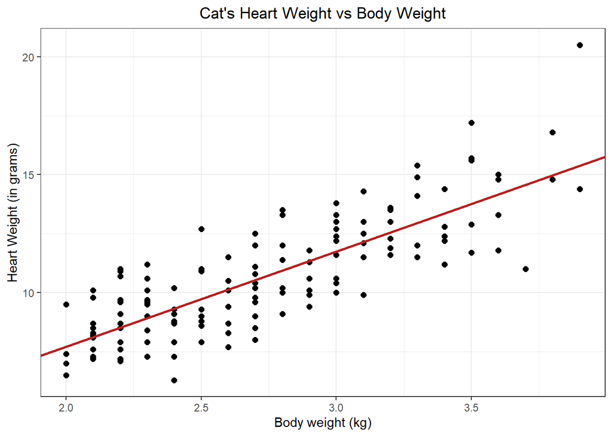

```r
library(ggplot2)
theme_set(theme_bw())
p = ggplot(cats,aes(Bwt, Hwt))
p = p + geom_point(size=2)#+  geom_smooth(method="lm", col="firebrick", size=1)
p = p + geom_abline(intercept=cat_model$coefficients[1], slope = cat_model$coefficients[2], color = "firebrick", size = 1)

p + labs(title = "Cat's Heart Weight vs Body Weight",  x = "Body weight (kg)", y = "Heart Weight (in grams)")+  theme(plot.title = element_text(hjust = 0.5))
```

**(f)** Report the value of $R^2$ for the model. Do so directly. Do not simply copy and paste the value from the full output in the console after running `summary()` in part **(a)**.

```r
summary(cat_model)$r.squared
```

```
## [1] 0.6466209
```

## Exercise 2 (Writing Functions)

This exercise is a continuation of Exercise 1.

**(a)** Write a function called `get_sd_est` that calculates an estimate of $\sigma$ in one of two ways depending on input to the function. The function should take three arguments as input:

- `fitted_vals` - A vector of fitted values from a model
- `actual_vals` - A vector of the true values of the response
- `mle` - A logical (`TRUE` / `FALSE`) variable which defaults to `FALSE`

The function should return a single value:

- $s_e$ if `mle` is set to `FALSE`.
- $\hat{\sigma}$ if `mle` is set to `TRUE`.

```r
get_sd_est <-function(fitted_vals,actual_vals, mle = FALSE )
{
  n = length(fitted_vals)
  e = actual_vals - fitted_vals
  if (mle==FALSE)
  {
    sd_est = sqrt(sum(e^2)/(n-2))
  }
  else
  {
    sd_est = sqrt(sum(e^2)/n)
  }

  return(sd_est)

}
```

**(b)** Run the function `get_sd_est` on the residuals from the model in Exercise 1, with `mle` set to `FALSE`. Explain the resulting estimate in the context of the model.

```r
get_sd_est(cat_model$fitted.values,cats$Hwt,mle = FALSE)
```

```
## [1] 1.452373
```

In context of problem its the estimated standard deviation of the error between fitted value of heart weight and true weight (in grams).

**(c)** Run the function `get_sd_est` on the residuals from the model in Exercise 1, with `mle` set to `TRUE`. Explain the resulting estimate in the context of the model. Note that we are trying to estimate the same parameter as in part **(b)**.

```r
get_sd_est(cat_model$fitted.values,cats$Hwt,mle = TRUE)
```

```
## [1] 1.442252
```

Given the observed heart weights (data) this is the estimated standard deviation that maximizes the joint probability (likelihood) that the observed heart weights were generated from the model.

**(d)** To check your work, output `summary(cat_model)$sigma`. It should match at least one of **(b)** or **(c)**.

```r
summary(cat_model)$sigma
```

```
## [1] 1.452373
```

## Exercise 3 (Simulating SLR)

Consider the model

$$Y_i = 5 + -3 x_i + \epsilon_i$$

with

$$\epsilon_i \sim N(\mu = 0, \sigma^2 = 10.24)$$

where $\beta_0 = 5$ and $\beta_1 = -3$.

This exercise relies heavily on generating random observations. To make this reproducible we will set a seed for the randomization. Alter the following code to make `birthday` store your birthday in the format: `yyyymmdd`. For example, [William Gosset](https://en.wikipedia.org/wiki/William_Sealy_Gosset), better known as *Student*, was born on June 13, 1876, so he would use:

```r
birthday = 12121977
set.seed(birthday)
```

**(a)** Use `R` to simulate `n = 25` observations from the above model. For the remainder of this exercise, use the following “known” values of $x$.

```r
sim_slr = function(x, beta_0 = 5, beta_1 = -3, sigma = 1) {
  n = length(x)
  epsilon = rnorm(n, mean = 0, sd = sigma)
  y = beta_0 + beta_1 * x + epsilon
  data.frame(predictor = x, response = y)
}
x = runif(n = 25, 0, 10)

std_dev = sqrt(10.24)
df = sim_slr(x, beta_0 = 5, beta_1 = -3, sigma = std_dev)
```

You may use [the `sim_slr` function provided in the text](http://daviddalpiaz.github.io/appliedstats/simple-linear-regression.html#simulating-slr). Store the data frame this function returns in a variable of your choice. Note that this function calls $y$ `response` and $x$ `predictor`.

**(b)** Fit a model to your simulated data. Report the estimated coefficients. Are they close to what you would expect? Briefly explain.

```r
fitted_model = lm(response ~ predictor, df)
fitted_model
```

```
##
## Call:
## lm(formula = response ~ predictor, data = df)
##
## Coefficients:
## (Intercept)    predictor
##       8.066       -3.379
```

The slope and intercept are close to expected slope and intercept.

**(c)** Plot the data you simulated in part **(a)**. Add the regression line from part **(b)** as well as the line for the true model. Hint: Keep all plotting commands in the same chunk.

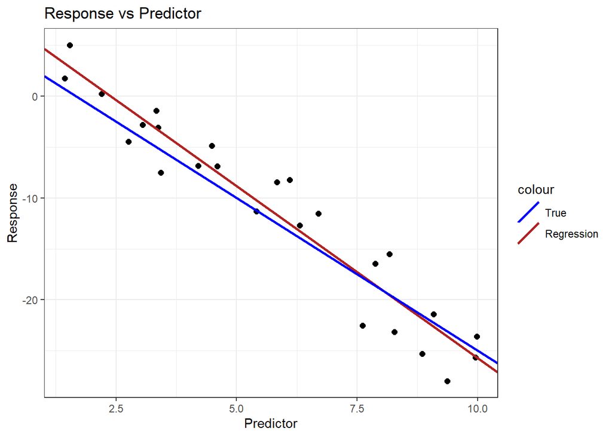

```r
p = ggplot(df,aes(predictor, response))
p = p + geom_point(size=2)+labs(title="Response vs Predictor ", x="Predictor", y="Response")
p = p + geom_abline(aes(intercept=fitted_model$coefficients[1], slope = fitted_model$coefficients[2], color = "firebrick"), size = 1)
p + geom_abline(aes(intercept=5, slope = -3 , color = "blue"), size = 1)+
  scale_color_identity(labels=c("True","Regression"), guide="legend")
```

**(d)** Use `R` to repeat the process of simulating `n = 25` observations from the above model $1500$ times. Each time fit a SLR model to the data and store the value of $\hat{\beta_1}$ in a variable called `beta_hat_1`. Some hints:

- Consider a `for` loop.
- Create `beta_hat_1` before writing the `for` loop. Make it a vector of length $1500$ where each element is `0`.
- Inside the body of the `for` loop, simulate new $y$ data each time. Use a variable to temporarily store this data together with the known $x$ data as a data frame.
- After simulating the data, use `lm()` to fit a regression. Use a variable to temporarily store this output.
- Use the `coef()` function and `[]` to extract the correct estimated coefficient.
- Use `beta_hat_1[i]` to store in elements of `beta_hat_1`.
- See the notes on [Distribution of a Sample Mean](http://daviddalpiaz.github.io/appliedstats/introduction-to-r.html#distribution-of-a-sample-mean) for some inspiration.

You can do this differently if you like. Use of these hints is not required.

```r
m = 1500
beta_hat_1 = rep(0,m)
for(i in 1:m)
{
  x = runif(n = 25, 0, 10)
  std_dev = sqrt(10.24)
  df = sim_slr(x, beta_0 = 5, beta_1 = -3, sigma = std_dev)
  fitted_model = lm(response ~ predictor, df)
  beta_hat_1[i] = fitted_model$coefficients[2]
}
```

**(e)** Report the mean and standard deviation of `beta_hat_1`. Do either of these look familiar?

```r
mean(beta_hat_1)
```

```
## [1] -3.007492
```

```r
sd(beta_hat_1)
```

```
## [1] 0.2312042
```

The mean of beta_hat_1 looks to be same as true mean as expected.

**(f)** Plot a histogram of `beta_hat_1`. Comment on the shape of this histogram.

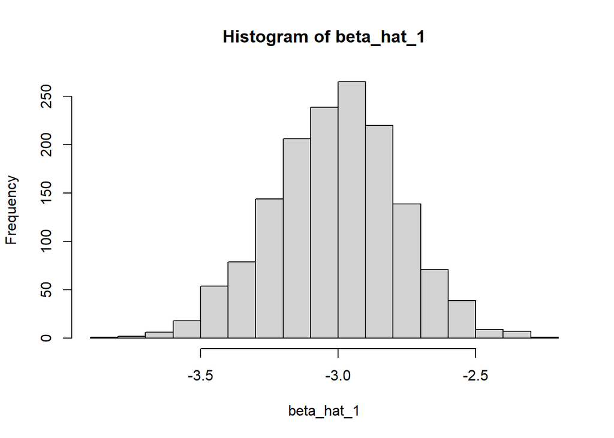

```r
hist(beta_hat_1)
```

The distribtion pfestimate of the slope $\hat{\beta_1}$ looks normal with mean as true slope (-3)

## Exercise 4 (Be a Skeptic)

Consider the model

$$Y_i = 3 + 0 \cdot x_i + \epsilon_i$$

with

$$\epsilon_i \sim N(\mu = 0, \sigma^2 = 4)$$

where $\beta_0 = 3$ and $\beta_1 = 0$.

Before answering the following parts, set a seed value equal to **your** birthday, as was done in the previous exercise.

```r
birthday = 010278
set.seed(birthday)
```

**(a)** Use `R` to repeat the process of simulating `n = 75` observations from the above model $2500$ times. For the remainder of this exercise, use the following “known” values of $x$.

```r
m = 2500
beta_hat_1 = rep(0,m)

for(i in 1:m)
{
  x = runif(n = 75, 0, 10)
  df = sim_slr(x, beta_0 = 3, beta_1 = 0, sigma = 2)
  fitted_model = lm(response ~ predictor, df)
  beta_hat_1[i] = fitted_model$coefficients[2]
}
```

Each time fit a SLR model to the data and store the value of $\hat{\beta_1}$ in a variable called `beta_hat_1`. You may use [the `sim_slr` function provided in the text](http://daviddalpiaz.github.io/appliedstats/simple-linear-regression.html#simulating-slr). Hint: Yes $\beta_1 = 0$.

**(b)** Plot a histogram of `beta_hat_1`. Comment on the shape of this histogram.

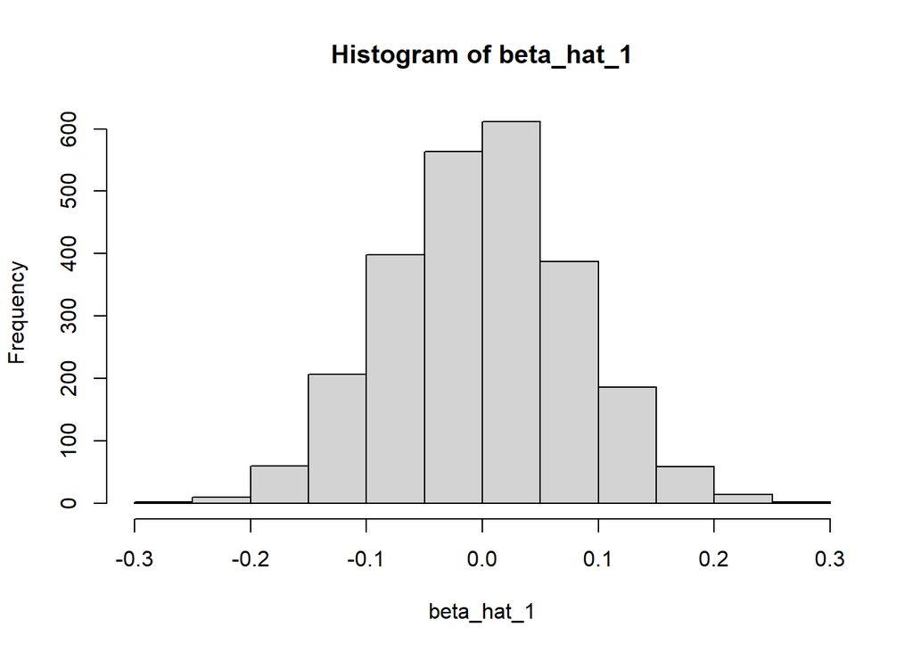

```r
hist(beta_hat_1)
```

The histogram of $\hat{\beta_1}$ looks like a normal distributed with mean of 0 (true mean from the model) .

**(c)** Import the data in `skeptic.csv` and fit a SLR model. The variable names in `skeptic.csv` follow the same convention as those returned by `sim_slr()`. Extract the fitted coefficient for $\beta_1$.

```r
df1 = read.csv("skeptic.csv")
fitted_model = lm(response ~ predictor, df1)
skeptic_beta_1  = fitted_model$coefficients[2]
skeptic_beta_1
```

```
##  predictor
## -0.2221927
```

**(d)** Re-plot the histogram from **(b)**. Now add a vertical red line at the value of $\hat{\beta_1}$ in part **(c)**. To do so, you’ll need to use `abline(v = c, col = "red")` where `c` is your value.

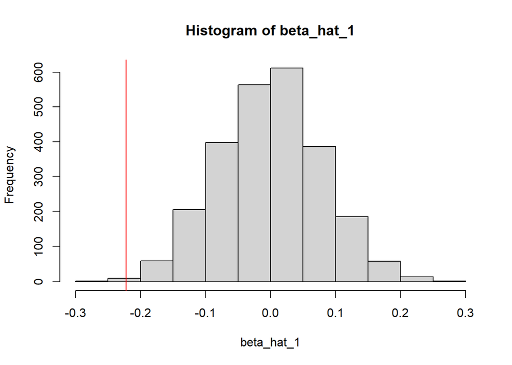

```r
hist(beta_hat_1)
abline(v = skeptic_beta_1, col = "red")
```

**(e)** Your value of $\hat{\beta_1}$ in **(c)** should be negative. What proportion of the `beta_hat_1` values is smaller than your $\hat{\beta_1}$? Return this proportion, as well as this proportion multiplied by `2`.

```r
mean(beta_hat_1 < skeptic_beta_1)
```

```
## [1] 0.002
```

```r
2*mean(beta_hat_1 < skeptic_beta_1)
```

```
## [1] 0.004
```

**(f)** Based on your histogram and part **(e)**, do you think the `skeptic.csv` data could have been generated by the model given above? Briefly explain.

The data in skeptic.csv is unlikely to be have been generated by the model since the proportion of beta_hat_1 that are smaller than beta1 from data is very small. There is little evidence to support it.

## Exercise 5 (Comparing Models)

For this exercise we will use the `Ozone` dataset from the `mlbench` package. You should use `?Ozone` to learn about the background of this dataset. You may need to install the `mlbench` package. If you do so, do not include code to install the package in your `R` Markdown document.

For simplicity, we will perform some data cleaning before proceeding.

```r
data(Ozone, package = "mlbench")
Ozone = Ozone[, c(4, 6, 7, 8)]
colnames(Ozone) = c("ozone", "wind", "humidity", "temp")
Ozone = Ozone[complete.cases(Ozone), ]
```

We have:

- Loaded the data from the package
- Subset the data to relevant variables
  - This is not really necessary (or perhaps a good idea) but it makes the next step easier
- Given variables useful names
- Removed any observation with missing values
  - This should be given much more thought in practice

For this exercise we will define the “Root Mean Square Error” of a model as

$$\text{RMSE} = \sqrt{\frac{1}{n} \sum_{i = 1}^{n}(y_i - \hat{y}_i)^2}.$$

**(a)** Fit three SLR models, each with “ozone” as the response. For the predictor, use “wind speed,” “humidity percentage,” and “temperature” respectively. For each, calculate $\text{RMSE}$ and $R^2$. Arrange the results in a markdown table, with a row for each model. Suggestion: Create a data frame that stores the results, then investigate the `kable()` function from the `knitr` package.

```r
library(knitr)
model_wind = lm(ozone ~ wind,  data = Ozone)
model_humidity = lm(ozone ~ humidity ,  data = Ozone)
model_temp = lm(ozone ~ temp,  data = Ozone)

#Wind
sum_wind = summary(model_wind)
e = model_wind$residuals
rmse_wind = sqrt(sum(e^2)/length(e))
wind = c(sum_wind$r.squared,rmse_wind )

#Humidity
sum_humidity= summary(model_humidity)
e = model_humidity$residuals
rmse_humidity = sqrt(sum(e^2)/length(e))
humidity = c(sum_humidity$r.squared, rmse_humidity)

#Temp
sum_temp= summary(model_temp)
e = model_temp$residuals
rmse_temp = sqrt(sum(e^2)/length(e))

temp = c(sum_temp$r.squared, rmse_temp)

model.comp  <- data.frame(rbind(wind, humidity, temp) )

colnames(model.comp) = c("$R Square$","RMSE")
```

|  | $R Square$ | RMSE |
| --- | --- | --- |
| wind | 0.0001402 | 7.961695 |
| humidity | 0.1941105 | 7.147822 |
| temp | 0.6042011 | 5.009257 |

**(b)** Based on the results, which of the three predictors used is most helpful for predicting ozone readings? Briefly explain.

Based on results the temperature predictor seems to be most useful since it has highest $R^2$ and lowest RMSE thus can explain the the variance of ozone better than other predictors.